# Setting Up R and RMarkdown

Pablo Barbera, Dan Cervone

March 30, 2016

Welcome to the workshop!

The goal of this first lesson is to provide an introduction to R for non-programmers. I will provide an overview of the fundamentals of this programming language, how to open and work with data in R, and best practices when coding in R.

**Why R?**

- Currently used by most statisticians and social scientists interested in data analysis; and also becoming one of most [popular languages in Data Science](http://www.kdnuggets.com/2015/05/r-vs-python-data-science.html).
- Open source: makes it highly customizable and easily extensible through [“packages”](https://cran.r-project.org/web/packages/) (over 7,500 and counting!).
- Powerful tool to conduct automated text analysis, social network analysis, and data visualization, with packages such as quanteda, igraph or ggplot2.
- Command-line interface and scripts favors reproducibility.
- Excellent documentation and online help resources.

We will be using [RStudio](https://www.rstudio.com/) to interact with R, and write our annotated R code using [Markdown](http://rmarkdown.rstudio.com).

**RStudio** is an open-source integrated development environment (IDE). The main advantage of RStudio with respect to other graphical interfaces, such as R GUI (the default), is that it integrates a powerful built-in text editor as well as other tools for plotting, debugging, and workspace management.

You can run each chunk of code one by one, by highlighting the code and clicking `Run` (or pressing `Ctrl + Enter` in Windows or `command + enter` in OS X). You can see the output of the code in the console right below, inside the RStudio window.

Alternatively, you can generate (or **knit**) an html document with all the code, comment, and output in the entire `.Rmd` file by clicking on `Knit HTML`.

You can also embed plots and graphics, for example:

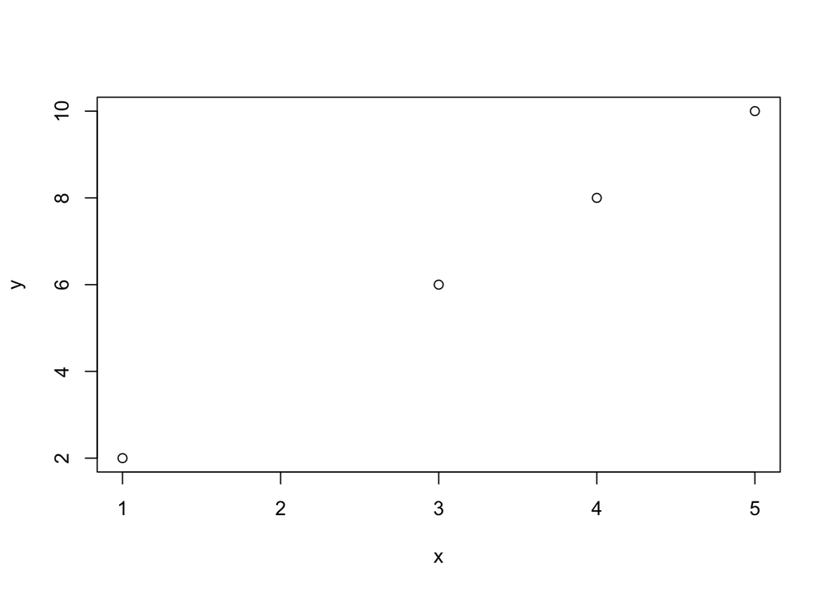

```r
x <- c(1, 3, 4, 5)
y <- c(2, 6, 8, 10)
plot(x, y)
```

If you run the chunk of code, the plot will be generated on the panel on the bottom right corner. If instead you knit the entire file, the plot will appear after you view the html document.

Using R + Markdown has several advantages: it leaves an “audit trail” of your work, including documentation explaining the steps you made. This is helpful to not only keep your own progress organized, but also make your work reproducible and more transparent. You can easily correct errors (just fix them and run the script again), and after you have finished, you can generate a PDF or HTML version of your work.

We will be exploring R through R Markdown over the next few modules. For more details and documentation see http://rmarkdown.rstudio.com.